# Betting-Time Analysis (Normal Condition Only)

analysis done by Henrik Singmann (singmann@gmail.com)

28 February, 2022

# Preparation

Total participants (NULL = did not pass captchas):

```
##
##  delay normal   NULL
##    502    502    182
```

Participants that passed the captchas and finished the study:

```
##
##      Normal Slowed-down
##         500         502
```

All following analysis only use the normal (i.e., not slowed down) condition.

# Distribution of Betting Times

We considered the time participants took for each round of roulette starting with the second round (as this was the first round to which the 1 minute slow down applied).

The first graph shows the distribution of individual betting times in seconds when restricting the shown range to up to 150 seconds. The first vertical line shows the overall median and the second line the overall mean (which as expected is strongly affected by the outliers on the right side).

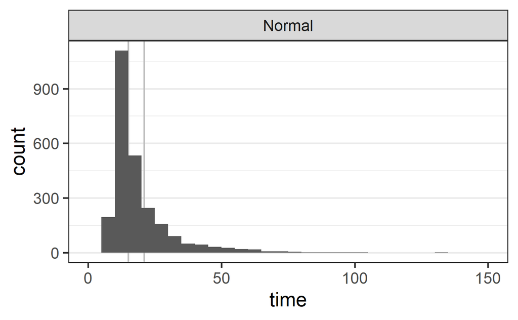

This plot excludes a few very long betting times.

```
## # A tibble: 2 x 3
##   ppt_id exp_cond  time
##   <chr>  <fct>    <dbl>
## 1 P0899  Normal     433
## 2 P0787  Normal     888
```

We can also look at some overall statistics of the betting times:

```
## # A tibble: 1 x 5
##   exp_cond time_mean time_median time_sd time_IQR
##   <fct>        <dbl>       <dbl>   <dbl>    <dbl>
## 1 Normal       20.95          15   25.73       10
```

Let’s take a look how the mean changes when using certain exclusion cut-offs (`co`):

```
## # A tibble: 1 x 9
##   exp_cond m_co_150 m_co_120 m_co_100 m_co_90 m_co_80 m_co_75 m_co_60 m_co_50
##   <fct>       <dbl>    <dbl>    <dbl>   <dbl>   <dbl>   <dbl>   <dbl>   <dbl>
## 1 Normal      19.77    19.58    19.41   19.26   19.15   18.97   18.37   17.65
```

These exclusion criteria would lead to the following proportions of excluded observations:

```
## # A tibble: 8 x 3
##   exp_cond cut_off     prop_excluded
##   <fct>    <chr>               <dbl>
## 1 Normal   prop_co_150       0.00466
## 2 Normal   prop_co_120       0.00621
## 3 Normal   prop_co_100       0.00777
## 4 Normal   prop_co_90        0.00971
## 5 Normal   prop_co_80        0.0117
## 6 Normal   prop_co_75        0.0136
## 7 Normal   prop_co_60        0.0260
## 8 Normal   prop_co_50        0.0443
```

# Distribution of mean betting times across participants

In the following output and plot, the value for `excl` (also given in the panel header) gives the cut-off for individual response times.

```
## # A tibble: 9 x 4
##    excl  mean median    sd
##   <dbl> <dbl>  <dbl> <dbl>
## 1    50  19.7   17.4  7.34
## 2    60  21.1   18.1  9.34
## 3    75  21.9   18.5 10.6
## 4    80  22.0   18.5 10.8
## 5    90  22.2   18.5 10.9
## 6   100  22.3   18.5 11.1
## 7   120  22.5   18.5 11.9
## 8   150  22.5   18.7 11.9
## 9   Inf  23.2   19   13.2
```

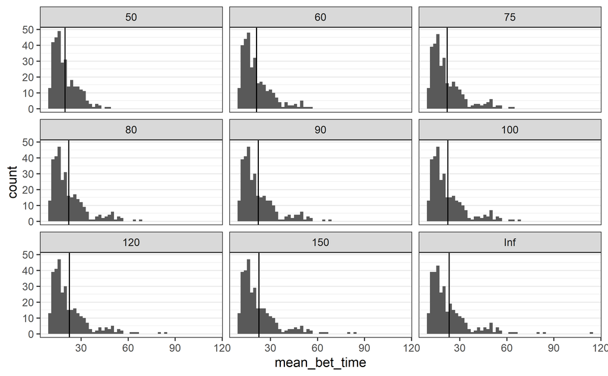

# Modelling mean betting times (cut-off: 90 seconds)